# Principles of Effective Antibiotic Therapy — Part 2

Lecture Handout — Slides 63+

Author

Prof. Russell E. Lewis, PharmD — Department of Molecular Medicine, University of Padua

Published

February 25, 2026

# 1 Pharmacokinetic/Pharmacodynamic (PK/PD) Indices

## 1.1 Three Patterns of Antibiotic Killing

One of the most important advances in modern antibiotic therapy is the recognition that antibiotics do not all kill bacteria in the same way. The relationship between drug concentrations and antimicrobial efficacy is described by **pharmacokinetic/pharmacodynamic (PK/PD) indices**, which link measurable drug exposure parameters to microbiological outcomes. Understanding these indices allows clinicians to rationally optimize dosing regimens rather than relying on one-size-fits-all approaches.

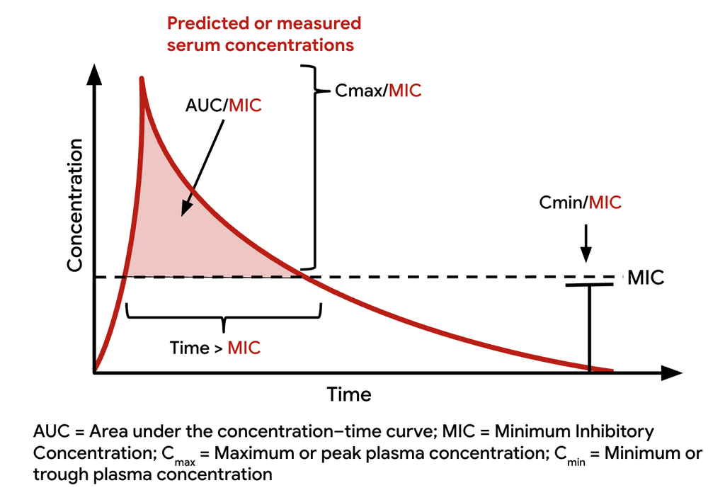

PK/PD indices relate drug concentration profiles to the MIC of the target pathogen. The three principal indices are Peak/MIC (concentration-dependent), Time above MIC (time-dependent), and AUC/MIC (exposure-dependent).

Three fundamental PK/PD patterns have been identified:

**Concentration-dependent killing (Peak/MIC).** For these antibiotics, the *height* of the peak concentration relative to the MIC is the primary driver of bacterial killing. The higher the peak above the MIC, the more rapid and complete the bactericidal effect. Drugs in this category include aminoglycosides, fluoroquinolones, and polymyxins. Clinical implication: when treating infections with higher MICs, it may be preferable to give a single higher dose rather than multiple smaller doses.

**Time-dependent killing (T > MIC).** For these antibiotics, efficacy depends on how long the drug concentration remains above the MIC during the dosing interval. Increasing the peak concentration does not substantially improve killing — what matters is *duration of exposure*. This pattern is characteristic of beta-lactams (penicillins, cephalosporins, carbapenems, monobactams) and macrolides. Animal and clinical studies have established that maintaining concentrations above the MIC for at least 40–50% of the dosing interval is generally associated with efficacy.

**Exposure-dependent killing (AUC/MIC).** These antibiotics exhibit a mixture of both time- and concentration-dependent activity. The total drug exposure over 24 hours — represented by the area under the concentration–time curve (AUC) divided by the MIC — best predicts outcomes. Vancomycin, tetracyclines, and linezolid fall into this category.

## 1.2 How PK/PD Indices Are Identified

PK/PD relationships are established through a combination of *in vitro* time-kill studies, animal infection models, and retrospective analyses of clinical data. Researchers measure the drug exposure associated with maximal efficacy (e.g., bacterial eradication, survival) and determine which PK/PD index best correlates with outcome.

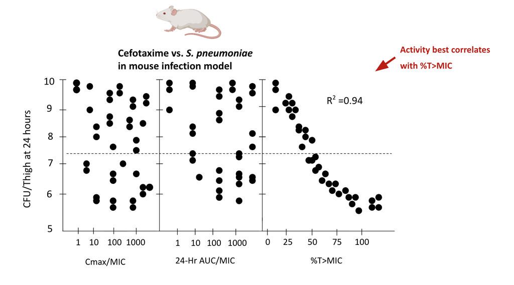

These studies have consistently shown that specific PK/PD targets predict clinical success. For example, for beta-lactams, a T > MIC of 40–50% is typically associated with microbiological efficacy, while for aminoglycosides a Peak/MIC ratio of 8–10 is optimal (Craig, 1998; Drusano, 2004).

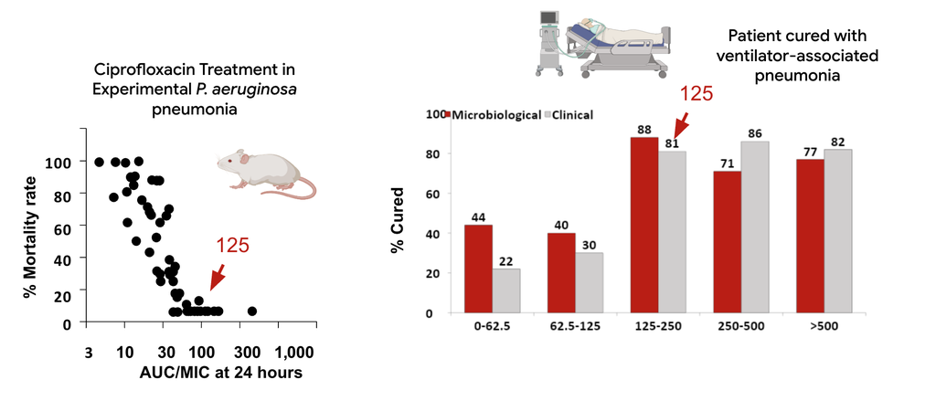

Clinical outcome data demonstrating the correlation between PK/PD index attainment and therapeutic success.

## 1.3 PK/PD Characteristics of Common Antibiotic Classes

The table below summarises the PK/PD classification of major antibiotic families and the corresponding optimisation strategies.

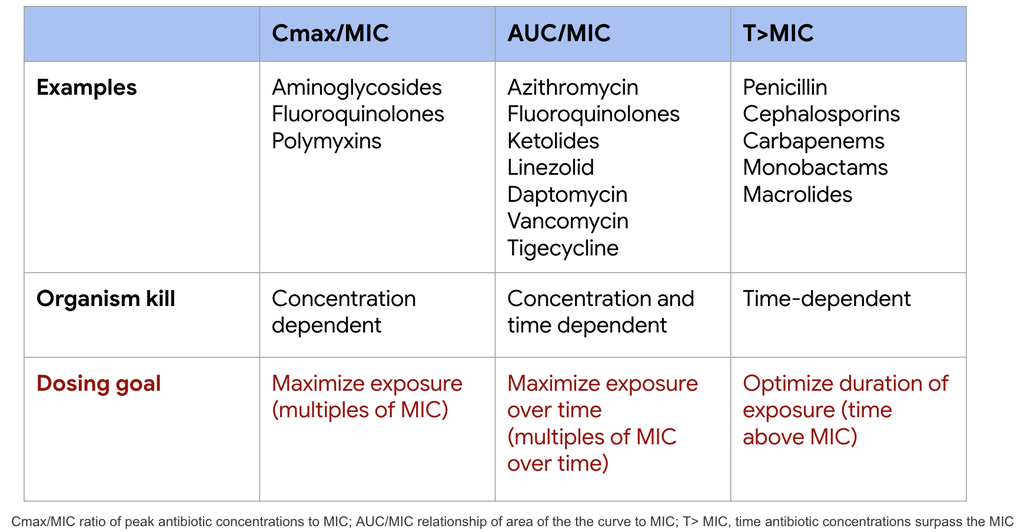

PK/PD characteristics of common antibiotic classes, showing the primary index for each drug family and the dosing strategy implied by the pharmacodynamic pattern.

**TipClinical Pearl — Dosing Strategy Follows the PK/PD Index**

For **concentration-dependent** drugs (aminoglycosides): give infrequent high doses (e.g., once-daily dosing). For **time-dependent** drugs (beta-lactams): give frequent doses or use extended/continuous infusions. For **AUC/MIC-dependent** drugs (vancomycin): optimise total daily exposure through AUC-guided monitoring.

# 2 Application: Model-Based Antibiotic Dosing Optimisation

## 2.1 From Population Models to Individualised Therapy

The practical importance of PK/PD indices is that they enable **model-based dosing** — a mathematically guided approach to individualising antibiotic therapy for each patient. This is particularly critical in the intensive care unit, where the pharmacokinetics of antibiotics are profoundly altered and the coefficient of variation in drug exposure can reach 80–100%.

The approach works as follows:

1. **Population pharmacokinetic models** are developed by studying hundreds or thousands of patients who received the drug. These models identify the clinical covariates (e.g., renal function, weight, albumin level, dialysis status) that significantly affect drug clearance and volume of distribution.
2. An **a priori prediction** is generated for a new patient based on their clinical characteristics. This provides a probability estimate that a given dosing regimen will achieve the PK/PD target (e.g., sufficient T > MIC for a beta-lactam).
3. **Therapeutic drug monitoring (TDM)** — measuring an actual drug level in the patient’s blood — is used to validate or refine the model prediction. If the measured concentration differs from the prediction, the model is adjusted (*Bayesian updating*) to produce a dosing regimen specific to that individual patient.
4. As the patient’s clinical status changes (e.g., declining renal function, fluid shifts), the model can be **continuously updated** to maintain optimal exposure.

## 2.2 Worked Example: Meropenem Dosing in the ICU

Consider a 35-year-old patient (70 kg, 170 cm) admitted after a motor vehicle accident who is becoming hypotensive and requires empirical broad-spectrum antibiotic therapy. Meropenem 1 g infused over 30 minutes every 8 hours (the standard licensed dose) is initiated.

Using a population PK model for meropenem in critically ill patients, we can predict the concentration–time profile. For a susceptible pathogen with an MIC of 2 mg/L (e.g., *E. coli*), the model estimates a T > MIC of approximately 93% — comfortably above the 40–50% target needed for efficacy.

**But what if the MIC is 16 mg/L?** Now the time above MIC falls to approximately 18–20%, well below the target. Simply doubling the dose to 2 g achieves only marginally better T > MIC, while producing dangerously high peak concentrations (approaching the seizure threshold of approximately 100 mg/L). The additional drug is essentially “wasted” — eliminated renally without contributing to bacterial killing.

**ImportantExtended Infusion — Optimising Time-Dependent Killing**

The solution exploits the PK/PD principle: since meropenem is time-dependent, we need to increase *duration of exposure*, not peak concentration. By infusing 1 g over 7.5 hours (instead of 30 minutes) every 8 hours, the T > MIC improves dramatically — approaching 100% even against the higher MIC target. Meropenem must be changed every 8 hours because of limited stability in solution, so a 7.5-hour infusion (with 30 minutes for the changeover) maximises infusion time within this constraint.

This model-based approach also allows clinicians to ask “what if” questions: *What if renal function declines? What if we need to cover a less susceptible pathogen?* The interactive TDMx platform (https://www.tdmx.eu/Launch-TDMx/) allows exploration of these scenarios for meropenem and other antibiotic classes such as aminoglycosides (Abdul-Aziz et al., 2015; Kothekar et al., 2020).

## 2.3 Hepatic Clearance and Drug Interaction Screening

Not all antibiotics are cleared renally. Several important antimicrobials (e.g., metronidazole, rifampin, certain macrolides, antifungals) undergo significant hepatic metabolism. For these drugs, hepatic dysfunction and drug–drug interactions become the primary concerns for dose adjustment.

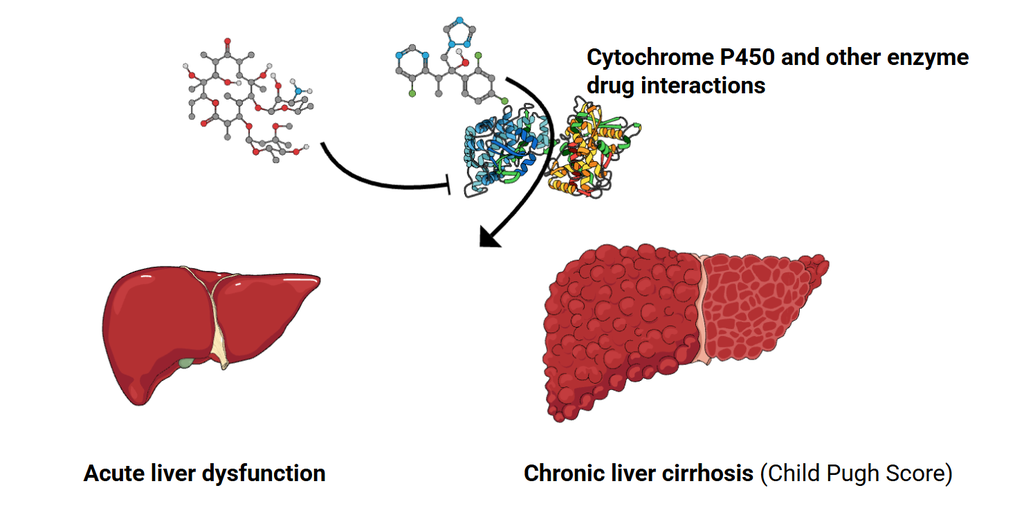

Hepatic clearance pathways for commonly used antibiotics.

Clinicians should routinely screen for drug interactions — particularly when using rifampin (a potent inducer of cytochrome P450 enzymes), azole antifungals (CYP inhibitors), or macrolides — using resources such as [UpToDate](https://www.uptodate.com/contents/search) or similar drug interaction databases.

# 3 Site-Specific Limitations of Antibiotic Activity

## 3.1 Daptomycin Inactivation in the Lung

Daptomycin is one of the most important antibiotics available for treating methicillin-resistant *Staphylococcus aureus* (MRSA). It is a rapidly bactericidal, concentration-dependent lipopeptide that was originally developed by Eli Lilly in the 1980s but abandoned after phase II trials revealed rhabdomyolysis (muscle damage leading to renal failure) when given three times daily. A biotech company (Cubist Pharmaceuticals) later applied PK/PD principles to recognise that daptomycin was concentration-dependent — a single daily dose both improved killing and reduced the risk of rhabdomyolysis (which was caused by persistent trough concentrations).

However, daptomycin has a critical limitation: **it is inactivated by pulmonary surfactant**. When daptomycin enters the lungs, it binds to surfactant and loses antimicrobial activity. This was discovered during a clinical trial for community-acquired pneumonia, in which daptomycin failed to demonstrate efficacy.

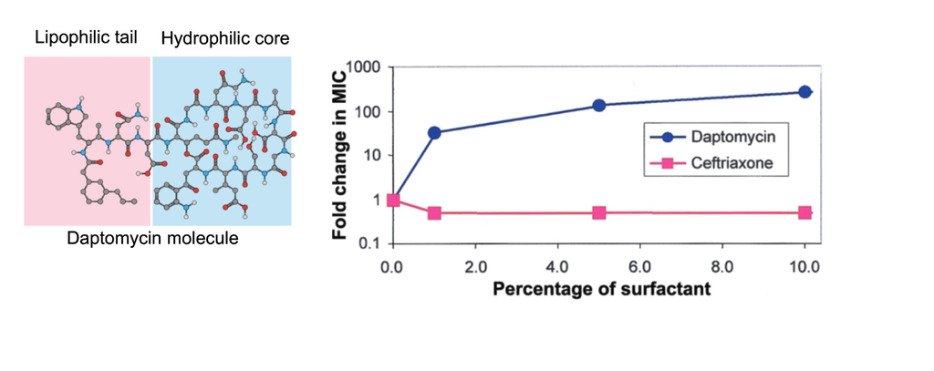

Daptomycin binding to pulmonary surfactant renders it inactive against *S. aureus* in the lung, despite excellent activity in the bloodstream and other tissues.

**WarningClinical Rule**

**Never use daptomycin to treat pneumonia** — regardless of the pathogen’s susceptibility. It will not achieve adequate antimicrobial activity in the pulmonary compartment.

## 3.2 Antibiotic Activity in Abscesses

Abscesses and large haematomas present another challenging environment for antibiotics. Several factors conspire to reduce drug activity:

- **Aminoglycosides** are bound and inactivated by purulent material. Low oxygen tension in abscesses impairs the active uptake of aminoglycosides into bacteria.
- **Penicillins and tetracyclines** are bound by haemoglobin and have reduced activity in the presence of haematoma formation.
- **Low pH** within abscesses further reduces the activity of many antibiotic classes.

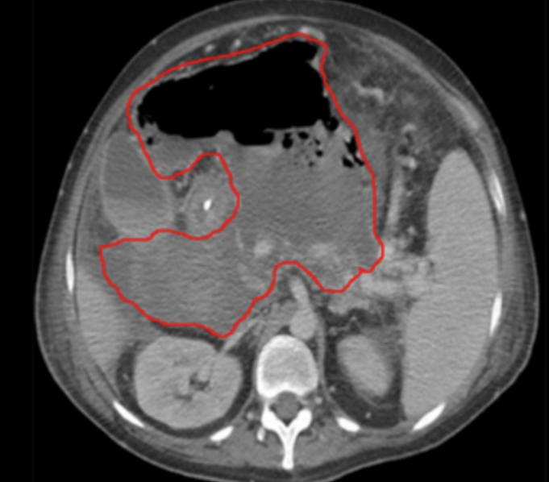

The hostile environment of an abscess — low pH, low oxygen tension, purulent material, and high bacterial density — impairs the activity of many antibiotics.

**ImportantSource Control Is Essential**

This is precisely why the management of many infections requires **source control** — surgical drainage of abscesses, evacuation of haematomas, or removal of infected prosthetic material. Antibiotics alone cannot reliably eradicate bacteria in these protected environments.

# 4 Principle 7: De-escalate Antibiotic Therapy Based on Microbiology Results and Clinical Biomarker Responses

## 4.1 The Rationale for De-escalation

Once microbiological data become available — typically 48–72 hours after cultures are obtained — clinicians should narrow the spectrum of antibiotic therapy to target only the identified pathogen(s). This **de-escalation** strategy reduces collateral damage to the patient’s microbiome, lowers the risk of *Clostridioides difficile* colitis, and minimises selection pressure for antibiotic resistance (Spellberg, 2025).

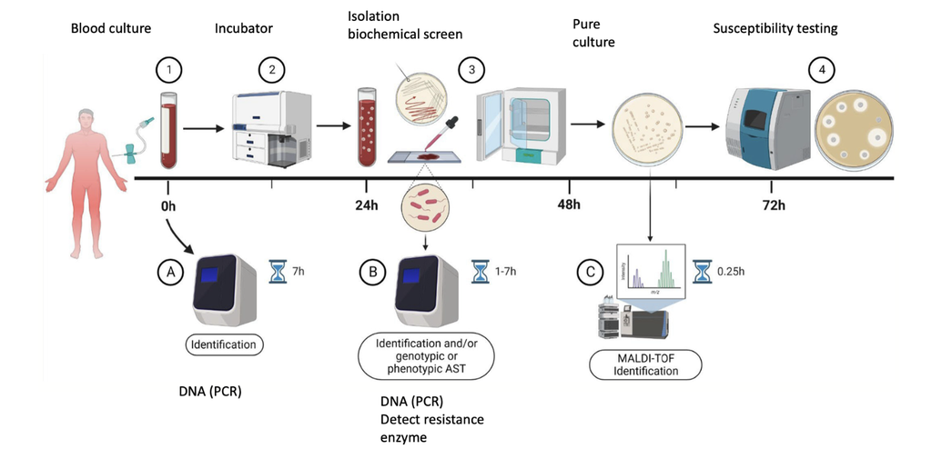

The de-escalation pathway: from empirical broad-spectrum therapy to targeted narrow-spectrum therapy guided by culture and susceptibility results.

Key opportunities for de-escalation include:

- **Stopping empirical vancomycin** when blood cultures grow only Gram-negative bacilli (no MRSA isolated).
- **Stopping broad-spectrum anti-resistant pathogen therapy** when cultures reveal susceptible organisms.
- **Narrowing from combination therapy to monotherapy** when a single effective agent is identified.

Remember: every additional day of unnecessary antibiotic therapy carries an approximately 3% increased risk of adverse drug events (Tamma et al., 2017).

## 4.2 Biomarkers for Guiding De-escalation

### 4.2.1 Fever and Leukocytosis

The most classic clinical markers of infection response are **temperature** and **white blood cell count**. For most infections, some improvement in both should be evident within 48–72 hours of initiating effective therapy. Persistent fever and leukocytosis beyond this window should prompt reconsideration of the diagnosis, adequacy of source control, or appropriateness of antibiotic selection.

### 4.2.2 C-Reactive Protein (CRP)

CRP is a non-specific marker of inflammation that rises in response to bacterial infection (particularly Gram-negative sepsis) and declines with successful treatment. However, its clinical utility for guiding antibiotic decisions is debated because it responds to many non-infectious inflammatory stimuli.

### 4.2.3 Procalcitonin (PCT)

Procalcitonin is a biomarker that rises more specifically in response to bacterial infections, especially Gram-negative sepsis. Multiple studies have demonstrated that **procalcitonin-guided algorithms** can safely reduce antibiotic duration — when procalcitonin declines below a threshold value, antibiotics can be discontinued with confidence (Schuetz et al., 2012).

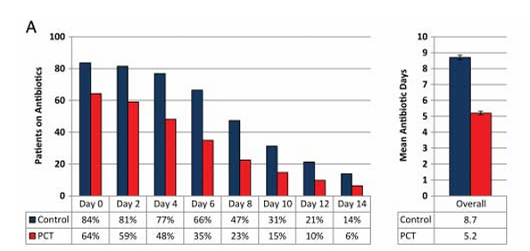

Meta-analysis data demonstrating that incorporation of procalcitonin into therapeutic decisions reduces antibiotic use.

**NoteThe Procalcitonin Paradox**

In practice, many clinicians use procalcitonin asymmetrically: they *ignore* negative results (which should prompt antibiotic discontinuation) while using positive results to *justify* continued therapy. This undermines the very purpose of the test. Procalcitonin requires its own stewardship programme and clear institutional guidelines for appropriate interpretation.

## 4.3 Gram Stain–Guided Therapy

The initial Gram stain remains a critical tool for early antibiotic selection: it immediately classifies the pathogen as Gram-positive or Gram-negative, allowing prompt narrowing of therapy even before full culture results are available.

A recent randomised clinical trial published in *JAMA Network Open* (GRACE-VAP trial) demonstrated that Gram stain–guided antibiotic selection for ventilator-associated pneumonia resulted in:

- A **30% reduction** in use of anti-pseudomonal agents
- A **40% reduction** in MRSA-directed agents
- Higher rates of appropriate antibiotic escalation (7% vs. 1%)

[figure not shown]

The GRACE-VAP trial demonstrated that Gram stain–guided initial antibiotic therapy leads to more appropriate antimicrobial use in ventilator-associated pneumonia.

These results confirm that investing in rapid microbiological diagnostics — even something as simple as a Gram stain — leads to more appropriate antimicrobial therapy and shorter courses of treatment (Yoshimura et al., 2022).

## 4.4 Interpreting Susceptibility Testing — Beyond S, I, and R

When susceptibility results return, many clinicians simply look for “S” (susceptible) and choose accordingly. However, this approach is dangerously oversimplified, particularly when dealing with resistant pathogens.

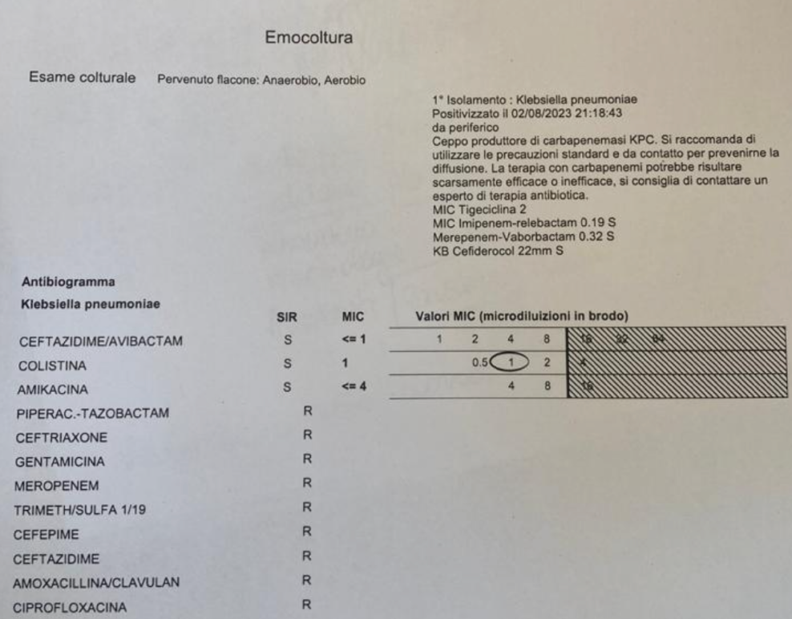

A susceptibility report for a KPC carbapenemase-producing *Klebsiella pneumoniae* — interpreting these results requires understanding MIC values, breakpoints, and the clinical pharmacology of each agent.

**WarningCritical Interpretation Points**

Consider a blood culture isolate of a KPC-producing *Klebsiella pneumoniae* that reports **ceftazidime-avibactam S (MIC < 1)**, **colistin S (MIC 1)**, and **amikacin S**:

1. **Ceftazidime-avibactam** has an MIC well below its breakpoint of 8 — the 3–4 dilution margin provides genuine confidence in efficacy.
2. **Colistin** has an MIC of 1, which is only one dilution below the resistance breakpoint of 2. Given that MIC testing has an inherent error of plus or minus one dilution (performing the test 10 times could yield results of 0.5, 1, 2, or even 4), this “S” result is essentially unreliable. Furthermore, colistin is clinically inferior — it is nephrotoxic, neurotoxic, has poor lung penetration, and carries high rates of spontaneous resistance.
3. **Amikacin** alone is insufficient as monotherapy for serious Gram-negative bloodstream infections.

The infectious disease specialist would recognise ceftazidime-avibactam as the clearly superior option, potentially combined with amikacin for the first 2–3 days until bloodstream clearance is confirmed. *S does not always mean S* — the clinical context, PK/PD characteristics, and limitations of the MIC test itself must all be considered.

Antibiotic stewardship programmes can leverage **selective reporting** by the microbiology laboratory — reporting only the most appropriate agents for a given pathogen — to guide clinician behaviour toward optimal antibiotic selection (Mouton et al., 2012).

# 5 Principle 8: If Therapy Is Not Working, Consider Source Control or Alternative Diagnosis Before Assuming Resistance

## 5.1 Recognising Treatment Failure

If the following parameters do not improve within 48–72 hours of initiating appropriate antibiotic therapy, treatment failure should be considered:

- Persistent or worsening **fever**
- Elevated **white blood cell count**
- Continuing **purulent secretions**
- Signs of inflammation: *rubor* (redness), *tumor* (swelling), *dolor* (pain), *calor* (warmth)
- Stagnant or rising **biomarkers** (procalcitonin, CRP)

**TipPractical Tip — The Pen Test for Cellulitis**

For cellulitis, draw a line around the advancing edge of erythema with a pen. Return in 12–24 hours: if the erythema is receding from the line, therapy is working. If it is advancing beyond the line, therapy may be failing.

## 5.2 Source Control — The Most Common Cause of Antibiotic Failure

Before assuming antibiotic resistance, clinicians must systematically evaluate whether there is an anatomical source that antibiotics cannot adequately penetrate:

Common source control problems requiring surgical or procedural intervention.

Occult subcutaneous abscess in cellulitis

New abscess formation in intra-abdominal infection

Empyema in community-acquired pneumonia

Visceral or skeletal abscess in bacteraemia

Failure to remove an infected central venous catheter

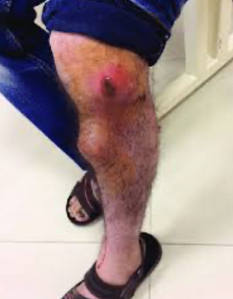

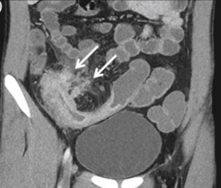

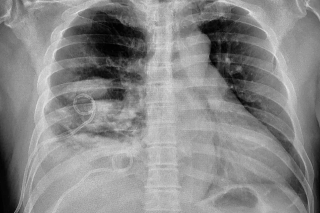

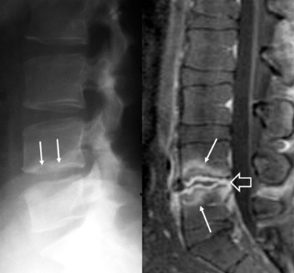

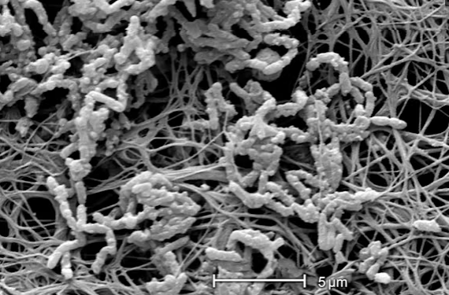

For many infections — particularly complicated cellulitis, intra-abdominal infections, and empyema — **the most important therapeutic intervention is not the antibiotic but the surgical procedure** (incision and drainage, percutaneous drainage, chest tube placement).

## 5.3 Biofilms: A Key Source of Antibiotic Failure

When bacteria colonise prosthetic materials (central venous catheters, prosthetic joints, heart valves, urinary catheters), they form **biofilm** — a glycopolysaccharide matrix that protects bacteria from both immune cells and antibiotics. Within a biofilm, bacteria exist in a spectrum of metabolic states: surface bacteria are metabolically active, but deeper layers become progressively dormant (“zombie” bacteria). Because beta-lactams require actively dividing bacteria to exert their effect, these dormant cells are intrinsically tolerant.

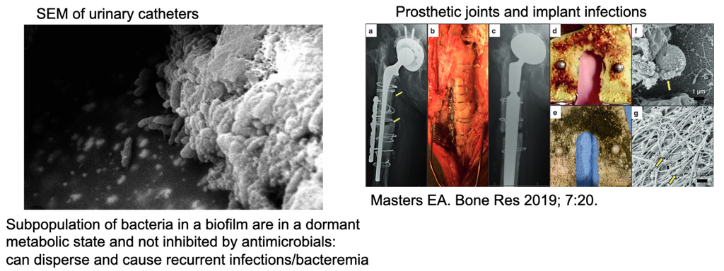

Biofilm structure on a prosthetic device. Bacteria within the biofilm are protected from antibiotics and immune defences, and periodically shed planktonic cells that cause recurrent bacteraemia.

Over time, fragments of biofilm detach and seed distant sites, causing recurrent bacteraemia.

**Management of catheter-related biofilm infections:**

- **High-virulence organisms** (e.g., *S. aureus*, *Candida* spp., *Pseudomonas aeruginosa*): the catheter **must be removed**. The risk of haematogenous seeding to bones, heart valves, and other sites is too high to justify salvage attempts.
- **Low-virulence organisms** (e.g., coagulase-negative staphylococci): catheter salvage with **antibiotic lock therapy** may be attempted, particularly if the catheter cannot easily be replaced. However, this approach is **never curative** — it only reduces the inoculum and delays recurrence.

**NoteThe Unmet Need**

If effective anti-biofilm therapies were developed, it would revolutionise the management of prosthetic device infections, urinary catheter infections, and many forms of recurrent bacteraemia. This remains one of the greatest unmet needs in infectious disease.

## 5.4 The FAIL Mnemonic

When a patient fails to respond to antibiotic therapy, systematically consider the **FAIL** construct:

- **F** — **False diagnosis** (wrong pathogen, non-infectious cause of fever such as malignancy, drug fever)
- **A** — **Allergies** (antibiotic-associated fever or rash; consider whether the antibiotic itself is causing the persistent fever)
- **I** — **Intercurrent infections** (a new or secondary infection has developed)
- **L** — **Localised process** (undrained abscess, infected prosthetic material, catheter-related infection)

**WarningAntibiotic-Associated Fever**

The longer a patient remains on antibiotics — particularly multiple agents — the greater the risk of **drug fever**. A clinically stable patient with low-grade fever on multiple antibiotics should prompt consideration of whether one of the antibiotics is the cause. This is particularly common in haematology-oncology patients receiving prolonged empirical therapy without a microbiological diagnosis.

# 6 Principle 9: Distinguish New Infection from Failure of Initial Therapy

New onset of infectious signs, symptoms, and biomarkers **after initial resolution** should raise concern for a **new infection** rather than persistence of the original one. Rarely, recrudescence may reflect emergence of antibiotic resistance from the initial pathogen — this is more commonly seen with certain organisms such as *Acinetobacter baumannii*.

Key management principles:

- Perform a **complete diagnostic re-evaluation**: new blood cultures, imaging, and clinical reassessment.
- It is generally reasonable to **broaden therapy** to cover highly resistant pathogens, as these patients have been exposed to recent antibiotics and carry a higher risk of resistant organisms.
- When changing antibiotics for breakthrough infection, **change one drug at a time** (to a different class if possible) to preserve the ability to assess which change was effective.
- If no source is identified despite thorough evaluation, it may ultimately be necessary to **stop all antibiotics** and allow the infection to “redeclare itself” — because continuing empirical therapy without a diagnosis will progressively reduce the probability of ever making one.

# 7 Principle 10: Shorter Is Better — Duration of Therapy Should Be Evidence-Based

## 7.1 The Shift from Tradition to Evidence

Historically, antibiotic treatment durations were based on tradition and clinical authority rather than evidence. Standard recommendations of 7, 14, 21, or 42 days — always fitting neatly into weekly multiples — were handed down through generations of teaching. These durations were never rigorously tested because early antibiotics were so obviously effective that formal duration trials were not conducted.

Over the past decade, numerous randomised controlled trials have systematically examined whether shorter courses are as effective as longer ones. The consistent finding has been: **shorter is better**.

## 7.2 Evidence for Short-Course Therapy

Evidence-based short-course antibiotic therapy: all studies demonstrated equivalent or lower mortality with shorter regimens (Spellberg, 2025).

| Infection | Short course (days) | Long course (days) | Outcome |
| --- | --- | --- | --- |
| Bacteraemia, Gram-negative | 7 | 14 | Equivalent |
| Chronic bronchitis / COPD | $\leq$ 5 | $\geq$ 7 | Equivalent |
| Intra-abdominal infection | 4 | 10 | Equivalent |
| Neutropenic fever | Until afebrile and stable | Until afebrile, stable, and non-neutropenic | Equivalent |
| Osteomyelitis, chronic | 42 | 84 | Equivalent |
| Pneumonia, community-acquired | 3–5 | 7–10 | Equivalent |
| Pneumonia, nosocomial (incl. VAP) | $\leq$ 8 | 10–15 | Equivalent |
| Pyelonephritis | 5–7 | 10–14 | Equivalent |
| Skin infections (cellulitis, abscess, wound) | 5–6 | 10–14 | Equivalent |
| Sinusitis, acute bacterial | 5 | 10 | Equivalent |

**TipWhy Shorter Can Mean Lower Mortality**

In several studies, shorter courses were associated with *lower* mortality than longer courses. The explanation is that shorter therapy produces fewer breakthrough resistant infections, fewer drug adverse events, and less disruption to the protective microbiome.

# 8 Common Myths of Antibiotic Therapy

## 8.1 Myth 1: Bactericidal Antibiotics Are More Effective Than Bacteriostatic

### 8.1.1 The Laboratory Definitions

The distinction between “bactericidal” and “bacteriostatic” is defined *in vitro*:

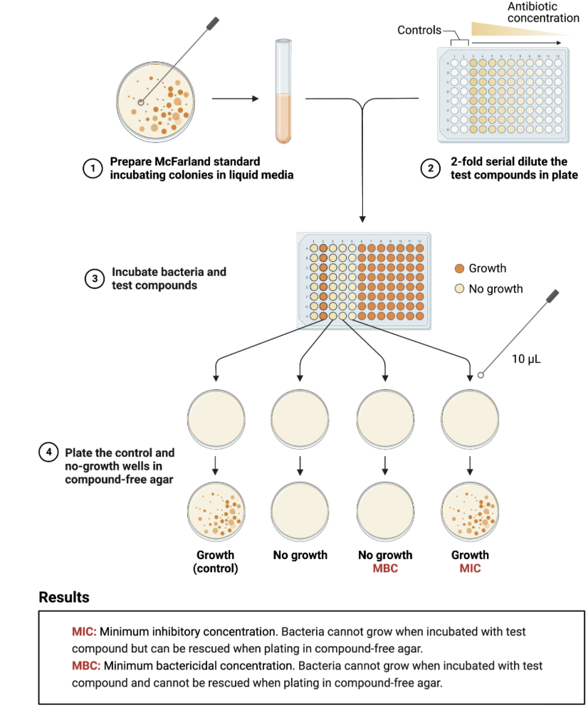

The relationship between MIC (minimum inhibitory concentration) and MBC (minimum bactericidal concentration). A drug is classified as bactericidal when the MBC is within 4-fold of the MIC.

However, this distinction is artificial — “bacteriostatic” drugs *do* kill bacteria, just at a slower rate or requiring higher concentrations to achieve the arbitrary 1000-fold threshold. All antibiotics kill; they kill at different rates and at different inocula.

### 8.1.2 The Evidence

A systematic literature review identified 49–56 randomised controlled trials comparing bacteriostatic and bactericidal agents. The results were unambiguous:

- **49 of 56 trials found no difference** in clinical outcomes, including in highly lethal infections in critically ill patients (typhoid fever, severe pneumonia, severe sepsis).
- **6 trials** actually found linezolid (classified as bacteriostatic) to be *superior* to bactericidal agents (vancomycin, teicoplanin, or cephalosporins).
- Only 1 trial found a bactericidal agent (imipenem) superior to a bacteriostatic one (tigecycline) in VAP — but the tigecycline dose was subsequently shown to have been too low. A follow-up study using double the dose found no difference (Wald-Dickler et al., 2017).

### 8.1.3 The Daptomycin vs. Vancomycin Example

Daptomycin — rapidly bactericidal — was widely expected to prove clinically superior to vancomycin — a slow-killing agent — for *S. aureus* bacteraemia. Despite its superior *in vitro* killing kinetics, **no clinical trial has demonstrated superiority of daptomycin over vancomycin** for this indication. Similarly, adding aminoglycosides to beta-lactams to accelerate killing of staphylococci has not improved clinical outcomes in trials, while increasing nephrotoxicity.

**NoteHistorical Artifact — Endocarditis**

The dogma that bactericidal antibiotics are required for endocarditis may reflect early studies that compared high-volume-of-distribution drugs (tetracyclines, macrolides — which achieve *low blood concentrations*) to penicillins (low Vd — *high blood concentrations*). The apparent inferiority of the “bacteriostatic” agents was likely due to inadequate drug exposure in the bloodstream, not an intrinsic difference in killing mechanism.

## 8.2 Myth 2: Oral Antibiotic Therapy Is Less Effective Than IV for Complex Infections

### 8.2.1 The Traditional Teaching

For decades, clinicians were taught that serious infections — particularly osteomyelitis, bacteraemia, and endocarditis — *required* intravenous therapy. This dogma kept patients hospitalised for weeks (e.g., 6 weeks of IV therapy for osteomyelitis) and exposed them to all the risks of prolonged central venous catheterisation.

### 8.2.2 The Evidence: Oral Is the New IV

Earlier failures with oral therapy (e.g., using oral sulfanilamide, erythromycin, or tetracycline for osteomyelitis) reflected the use of drugs with poor bioavailability that could not achieve concentrations in blood and bone exceeding the pathogen MIC. Modern oral antibiotics — particularly fluoroquinolones, linezolid, trimethoprim-sulfamethoxazole, and others — have excellent bioavailability and achieve tissue concentrations well above target MICs.

Systematic reviews and meta-analyses have now demonstrated:

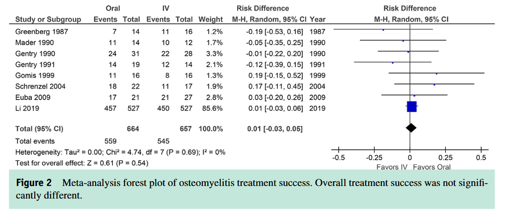

Meta-analysis forest plots comparing IV versus oral antibiotic therapy for osteomyelitis, bacteraemia, and endocarditis. Results favoured oral therapy or showed no difference.

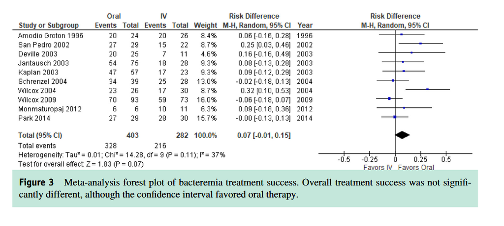

Bacteraemia meta-analysis: oral therapy associated with equivalent or better outcomes.

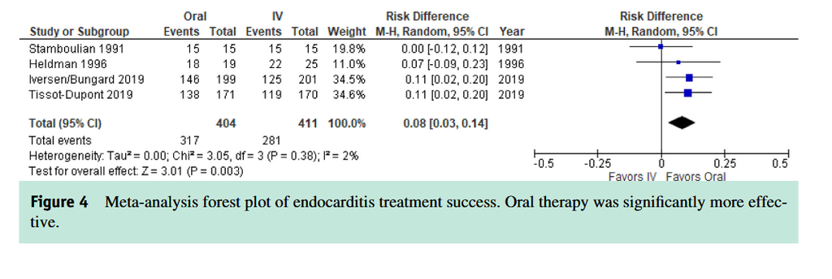

Endocarditis meta-analysis: oral step-down therapy associated with equivalent or better outcomes.

The superior outcomes with oral therapy are likely explained by lower complication rates (no catheter infections, fewer drug errors, greater patient satisfaction) rather than inherent superiority of the oral route (Wald-Dickler et al., 2022).

### 8.2.3 When Oral Therapy Is Not Appropriate

The switch to oral therapy requires that **all** of the following conditions are met:

1. The patient is **haemodynamically stable**
2. The patient has a **functioning gastrointestinal tract** (will absorb the drug)
3. The patient **can reliably take medications by mouth**
4. An oral antibiotic with **adequate bioavailability** exists for the target pathogen

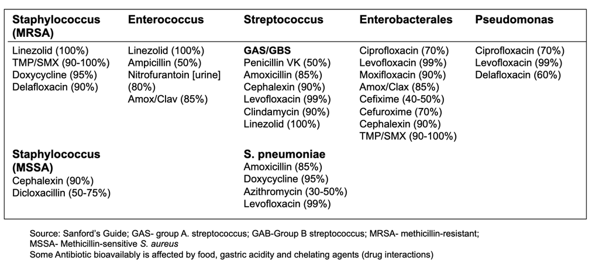

Oral bioavailability of common antibiotics — drugs with high bioavailability (approaching 100%) are ideal candidates for IV-to-oral switch therapy.

**NoteEmerging Options — Ultra-Long-Acting Antibiotics**

New antibiotics with very long half-lives (administered every 1–2 weeks by injection) are being explored as alternatives for conditions like osteomyelitis: the patient receives an injection, goes home, and returns to the day hospital two weeks later for the next dose. This approach eliminates the need for both prolonged hospitalisation and daily oral adherence.

## 8.3 Myth 3: Combination Therapy — The Good, the Bad, and the Ugly

### 8.3.1 The Good: When Combination Therapy Is Beneficial

There are specific, well-established indications for combination antibiotic therapy:

**1. Expanding the spectrum of coverage.** When the likely pathogen spectrum cannot be covered by a single agent — for example, treating community-acquired pneumonia with a beta-lactam (for *Streptococcus pneumoniae*) plus a macrolide (for atypical pathogens such as *Mycoplasma* or *Legionella*). Similarly, in ICU settings with high rates of multi-drug resistance, two drugs may provide broader empirical coverage.

**2. Preventing emergence of resistance in specific scenarios:**

- **Tuberculosis**: slow growth, non-replicating persister cells in cavitary disease can achieve high bacterial densities with spontaneous resistance mutations. Multi-drug regimens (3–4 drugs) dramatically reduce the probability of resistance emergence.
- **HIV and hepatitis C**: resistance converts a treatable/curable infection into a fatal illness, making combination therapy essential.

**3. Superior outcomes with two active agents for specific pathogen biology:**

- **Bone and joint infections**: non-replicating bacteria in biofilm respond poorly to beta-lactams alone. The addition of **rifampin** (which penetrates biofilm and kills dormant cells) — particularly in combination with a fluoroquinolone — has been associated with reduced relapse rates in prosthetic joint infections.
- **Eukaryotic infections**: cryptococcal meningitis (amphotericin B + 5-FC), protozoal infections (*Plasmodium*: primaquine added to kill hepatic hypnozoites), acute amoebic colitis (metronidazole + luminal agent), nematode infections (doxycycline added to kill *Wolbachia* commensals), and neurocysticercosis (albendazole + praziquantel for dual killing mechanisms and PK synergy).

**4. Exotoxin-producing infections.** In necrotising fasciitis caused by streptococci or *Clostridium* species, the addition of a **protein synthesis inhibitor** (clindamycin or linezolid) to backbone beta-lactam therapy shuts down bacterial toxin production. This has been associated with improved survival in retrospective studies.

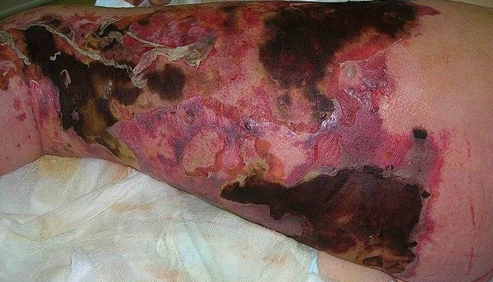

Necrotising fasciitis — an aggressive, toxin-mediated infection in which the addition of a protein synthesis inhibitor to backbone therapy improves outcomes.

### 8.3.2 The Microbiological Rationale: Checkerboard Testing

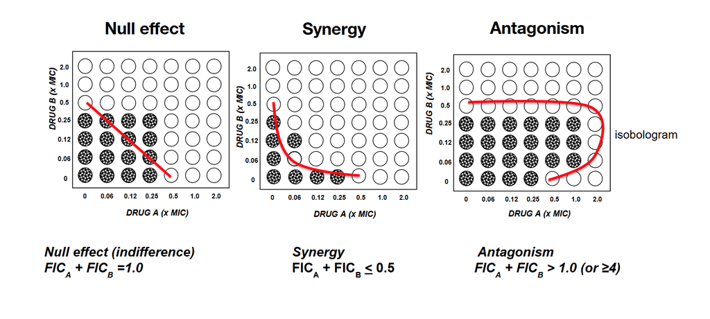

The checkerboard test for antibiotic synergy — a microtitre plate array testing all combinations of two drugs at varying concentrations.

However, there is very little evidence that *in vitro* synergy testing predicts clinical outcomes, and this test is almost never performed routinely in clinical microbiology laboratories.

### 8.3.3 The Bad: Redundant Combination Therapy for Typical Infections

For acute pyogenic bacterial infections, there is **very little evidence** supporting routine use of two active agents:

- These organisms are in planktonic (free-floating) growth, not multiple life cycle phases
- There are no commensal organisms inside the bacteria to target
- The pharmacology and killing activity of single agents is generally adequate

The classic example is *Pseudomonas aeruginosa*. For decades, clinicians were taught to always use combination therapy (typically an aminoglycoside plus a beta-lactam) for Pseudomonas infections. Meta-analyses have consistently found **no advantage** for dual therapy, while combination regimens result in higher rates of nephrotoxicity and microbiome disruption.

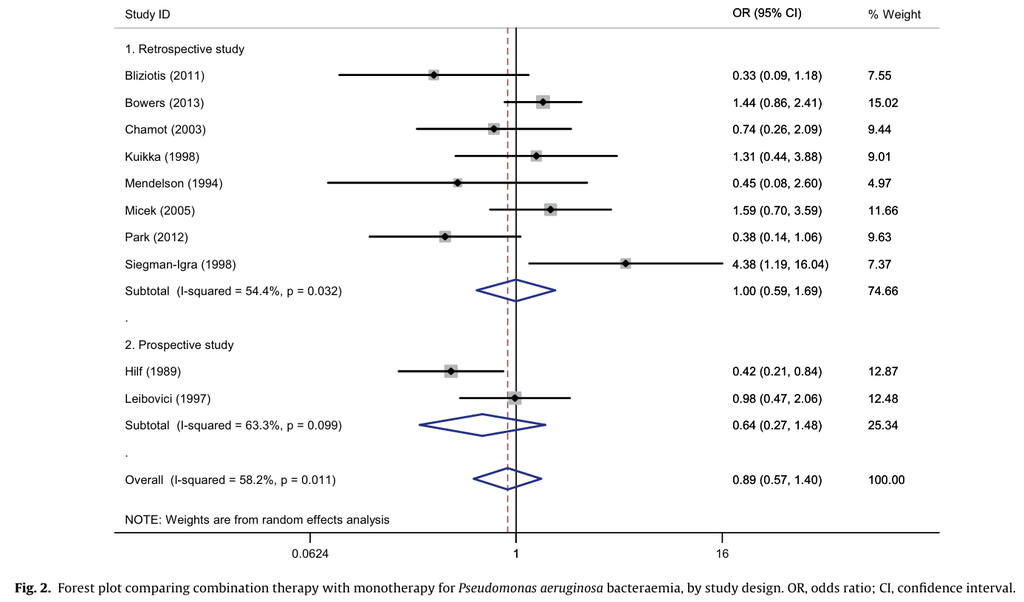

A pragmatic approach used in many centres is to initiate combination therapy empirically (e.g., piperacillin-tazobactam plus an aminoglycoside), then **discontinue the aminoglycoside after 2–3 days** once blood culture results are available and the patient is clinically improving. This limits toxicity while providing initial broad coverage (Hu et al., 2013).

### 8.3.4 The Ugly: Imperfect Data

Several areas remain genuinely uncertain:

- **Fungal infections beyond cryptococcosis**: combination therapy for *Candida* infections has shown no clear benefit; for *Aspergillus* infections, there is possible benefit with echinocandins plus triazoles, but data remain incomplete.
- **Does combination therapy prevent resistance?** Yes — for tuberculosis, HIV, and HCV. For acute pyogenic bacterial infections, the in vitro rationale exists but clinical proof is lacking. It may even be a **Pyrrhic victory**: more drugs mean greater selection pressure on the microbiome and potentially greater selection for multi-drug resistance.

# 9 Conclusions

Antibiotic therapy represents one of the great miracles of modern medicine — fundamentally altering the practice of medicine and saving countless lives. Yet the incredible power of these drugs is fleeting: resistance is an inevitable consequence of antibiotic use, and every unnecessary dose accelerates its emergence.

The 10 Principles of Effective Antibiotic Therapy provide a framework for responsible prescribing:

1. **Start antibiotics promptly** when infection is suspected
2. **Obtain cultures before therapy** whenever possible
3. **Choose empirical therapy** based on the most likely pathogen and local resistance patterns
4. **Understand PK/PD** to optimise dosing for the site and severity of infection
5. **Adjust for the host** — consider renal function, hepatic clearance, and patient-specific factors
6. **Know the site** — some drugs do not work in certain compartments
7. **De-escalate** based on microbiology results and biomarker responses
8. **Evaluate source control** before assuming resistance
9. **Distinguish new infection** from treatment failure
10. **Keep it short** — evidence supports shorter courses for most infections

Three enduring myths must also be retired from clinical practice: the bactericidal/bacteriostatic dichotomy is not clinically meaningful, oral therapy is appropriate for many serious infections, and combination therapy is beneficial only in specific well-defined scenarios.

Physicians bear the burden of using antibiotics effectively — to heal and cure patients while preserving this extraordinary therapeutic resource for future generations.

## 10 References

Abdul-Aziz M, Lipman J, Mouton J, Hope W, Roberts J. Applying Pharmacokinetic/Pharmacodynamic Principles in Critically Ill Patients: Optimizing Efficacy and Reducing Resistance Development. Seminars in Respiratory and Critical Care Medicine 2015;36:136–53. https://doi.org/10.1055/s-0034-1398490.

Craig WA. Pharmacokinetic/pharmacodynamic parameters: Rationale for antibacterial dosing of mice and men. Clinical Infectious Diseases 1998;26:1–10. https://doi.org/10.1086/516284.

Drusano GL. Antimicrobial pharmacodynamics: critical interactions of ’bug and drug’. Nature Reviews Microbiology 2004;2:289–300. https://doi.org/10.1038/nrmicro862.

Hu Y, Li L, Li W, Xu H, He P, Yan X, et al. Combination antibiotic therapy versus monotherapy for pseudomonas aeruginosa bacteraemia: A meta-analysis of retrospective and prospective studies. International Journal of Antimicrobial Agents 2013;42:492–6. https://doi.org/10.1016/j.ijantimicag.2013.09.002.

Kothekar AT, Divatia JV, Myatra SN, Patil A, Nookala Krishnamurthy M, Maheshwarappa HM, et al. Clinical pharmacokinetics of 3-h extended infusion of meropenem in adult patients with severe sepsis and septic shock: implications for empirical therapy against Gram-negative bacteria. Annals of Intensive Care 2020;10:4. https://doi.org/10.1186/s13613-019-0622-8.

Mouton JW, Brown DFJ, Cantón R, Giske CG, Ivanova M, MacGowan AP, et al. The role of pharmacokinetics/pharmacodynamics in setting clinical MIC breakpoints: the EUCAST approach. Clinical Microbiology and Infection 2012;18:E37–45. https://doi.org/10.1111/j.1469-0691.2011.03752.x.

Schuetz P, Briel M, Christ-Crain M, Stolz D, Bouadma L, Wolff M, et al. Procalcitonin to guide initiation and duration of antibiotic treatment in acute respiratory infections: An individual patient data meta-analysis. Clinical Infectious Diseases 2012;55:651–62. https://doi.org/10.1093/cid/cis464.

Spellberg B. Principles of antibiotic therapy. Mandell, douglas, and bennett’s principles and practice of infectious diseases 10th edition, vol. 1. 10th ed., 2025, p. 218–28.

Tamma PD, Avdic E, Li DX, Dzintars K, Cosgrove SE. Association of adverse events with antibiotic use in hospitalized patients. JAMA Internal Medicine 2017;177:1308–15. https://doi.org/10.1001/jamainternmed.2017.1938.

Wald-Dickler N, Holtom PD, Phillips MC, Centor RM, Lee RachaelA, Baden R, et al. Oral is the new IV. Challenging decades of blood and bone infection dogma: A systematic review. The American Journal of Medicine 2022;135:369–379.e1. https://doi.org/10.1016/j.amjmed.2021.10.007.

Wald-Dickler N, Holtom P, Spellberg B. Busting the myth of “static vs. Cidal”: A systemic literature review. Clinical Infectious Diseases: An 2017. https://doi.org/10.1093/cid/cix1127.

Yoshimura J, Yamakawa K, Ohta Y, Nakamura K, Hashimoto H, Kawada M, et al. Effect of gram stain–guided initial antibiotic therapy on clinical response in patients with ventilator-associated pneumonia: The GRACE-VAP randomized clinical trial. JAMA Network Open 2022;5:e226136. https://doi.org/10.1001/jamanetworkopen.2022.6136.